# Best Practices in Data Visualization

# Getting Started

### Download the Data

```r
# Install required packages if not already installed
if (!requireNamespace("arrow", quietly = TRUE)) {
  install.packages("arrow")
}
if (!requireNamespace("tidyverse", quietly = TRUE)) {
  install.packages("tidyverse")
}
if (!requireNamespace("ggdist", quietly = TRUE)) {
  install.packages("ggdist")
}
if (!requireNamespace("ggpmisc", quietly = TRUE)) {
  install.packages("ggpmisc")
}

suppressPackageStartupMessages(library(tidyverse))

# Set ggplot theme
theme_ns <- theme(text = element_text(family = "Helvetica"),
                  title = element_text(size = 14, margin = margin(0, 0, 8, 0)),
                  plot.subtitle = element_text(size = 12, face = "plain", hjust = 0),
                  plot.title = element_text(hjust = 0),
                  axis.title = element_text(size = 12, face = "bold", margin = margin(4,4,4,4)),
                  axis.title.x.bottom = element_text(face = "bold", margin = margin(4,0,0,0)),
                  axis.title.y.left = element_text(face = "bold", margin = margin(0,4,0,0)),
                  legend.title = element_text(face = "bold.italic", size = 12),
                  axis.line = element_line(),
                  axis.ticks = element_blank(),
                  panel.grid = element_blank(),
                  panel.background = element_blank(),
                  strip.text = element_text(size = 10, face = "bold.italic"),
                  strip.background = element_blank())
theme_set(theme_ns)

# Download BMP data for analysis
bmp_data <- arrow::read_feather("../inputs/bmp_data.feather")
```

# Exercise 1: Best Practices

## Comparing Distributions

Let’s start by comparing the distributions of potassium results.

**Base**

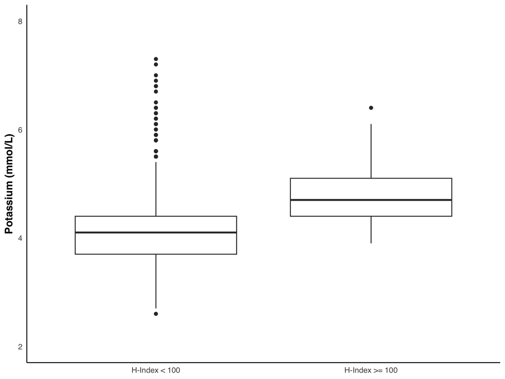

```r
bmp_data |>
  slice_head(n = 1000) |>
  ggplot(aes(y = potassium_plas, x = luo_h > 100)) +
    geom_boxplot() +
    scale_y_continuous(name = "Potassium (mmol/L)", limits = c(2, 8)) +
    scale_x_discrete(name = "Hemolysis", limits = c(F, T), labels = c("H-Index < 100", "H-Index >= 100")) +
    theme(axis.title.x.bottom = element_blank())
```

**Good**

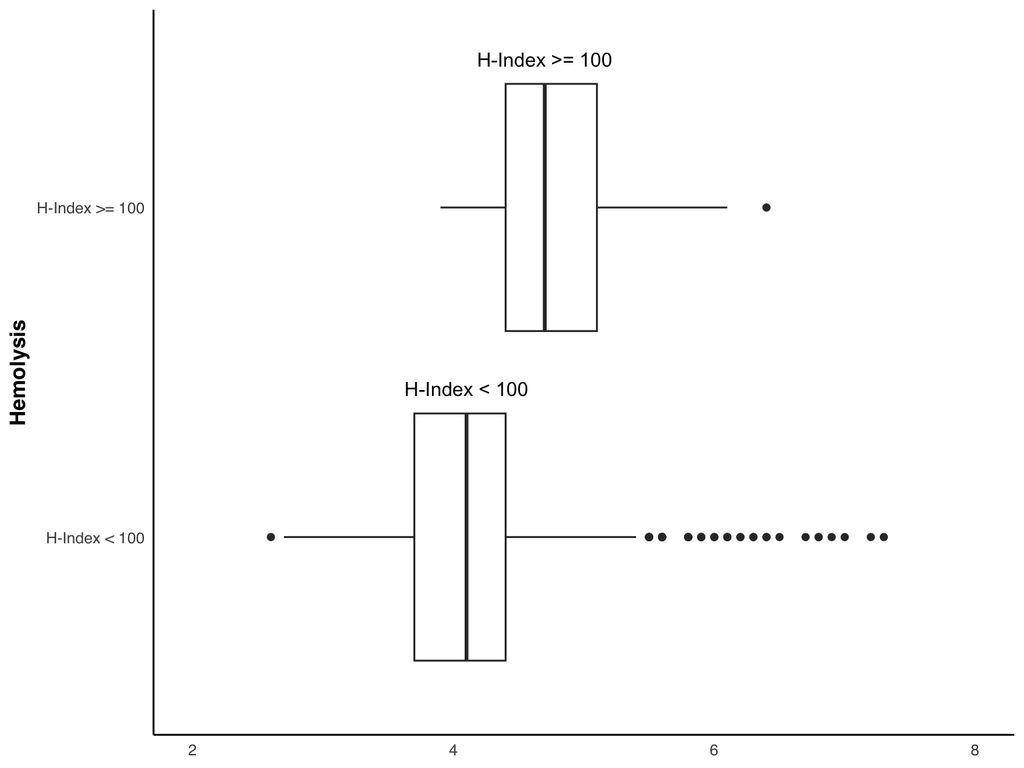

```r
bmp_data |>
  slice_head(n = 1000) |>
  ggplot(aes(x = potassium_plas, y = luo_h > 100)) +
    geom_boxplot() +
    geom_text(data = tibble(x = c(4.1, 4.7), y = c(1.45, 2.45), label = c("H-Index < 100", "H-Index >= 100")), aes(x = x, y = y, label = label)) +
    scale_x_continuous(name = "Potassium (mmol/L)", limits = c(2, 8)) +
    scale_y_discrete(name = "Hemolysis", limits = c(F, T), labels = c("H-Index < 100", "H-Index >= 100")) +
    theme(axis.title.x.bottom = element_blank())
```

**Better**

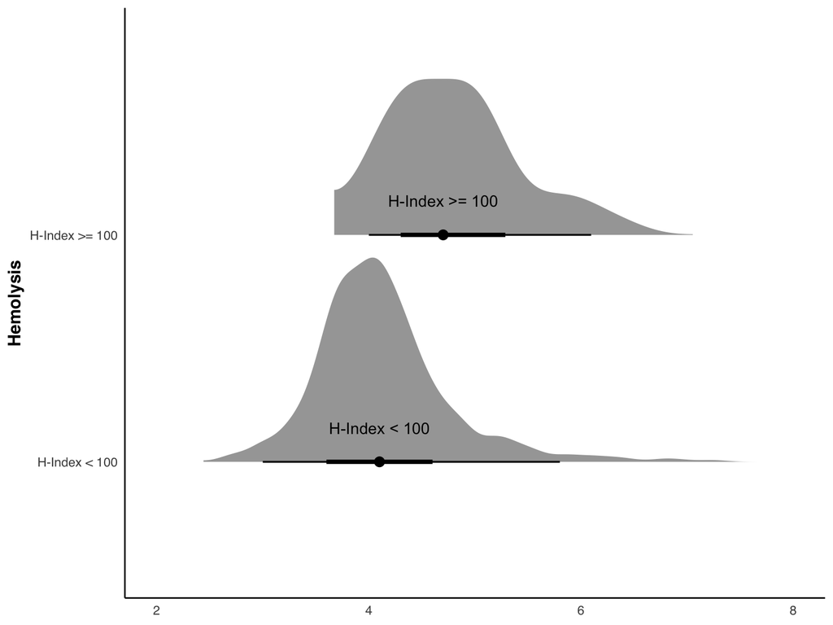

```r
bmp_data |>
  slice_head(n = 1000) |>
  ggplot(aes(x = potassium_plas, y = luo_h > 100)) +
    ggdist::stat_halfeye(trim = F) +
    geom_text(data = tibble(x = c(4.1, 4.7), y = c(1.15, 2.15), label = c("H-Index < 100", "H-Index >= 100")), aes(x = x, y = y, label = label)) +
    scico::scale_fill_scico_d() +
    scale_x_continuous(name = "Potassium (mmol/L)", limits = c(2, 8)) +
    scale_y_discrete(name = "Hemolysis", limits = c(F, T), labels = c("H-Index < 100", "H-Index >= 100")) +
    theme(axis.title.x.bottom = element_blank())
```

**Best**

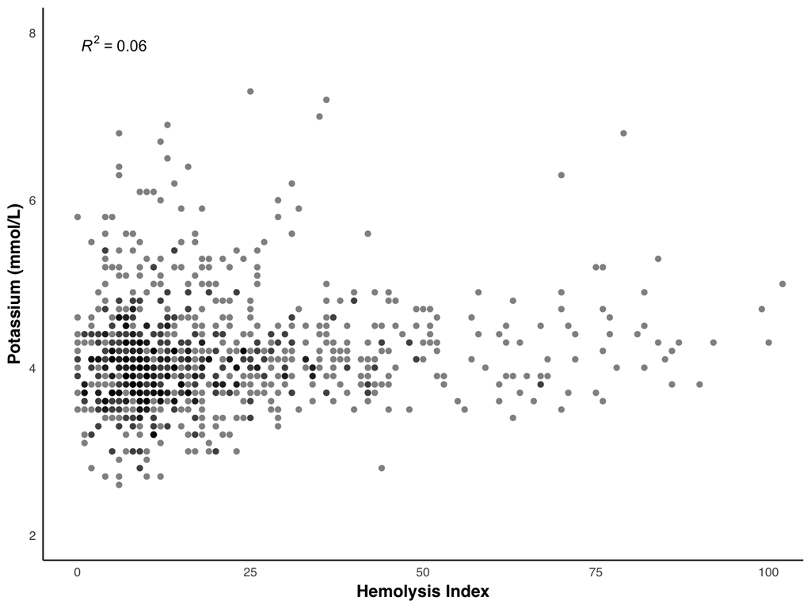

```r
bmp_data |>
  slice_head(n = 1000) |>
  ggplot(aes(y = potassium_plas, x = luo_h)) +
    geom_point(alpha = 0.5, size = 2, stroke = 0.1) +
    ggpmisc::stat_poly_eq() +
    scale_y_continuous(name = "Potassium (mmol/L)", limits = c(2, 8)) +
    scale_x_continuous(name = "Hemolysis Index") +
    coord_cartesian(xlim = c(0, 100)) +
    theme()
```

## Comparing Proportions

Next, let’s explore how we might best display proportions.

**Base**

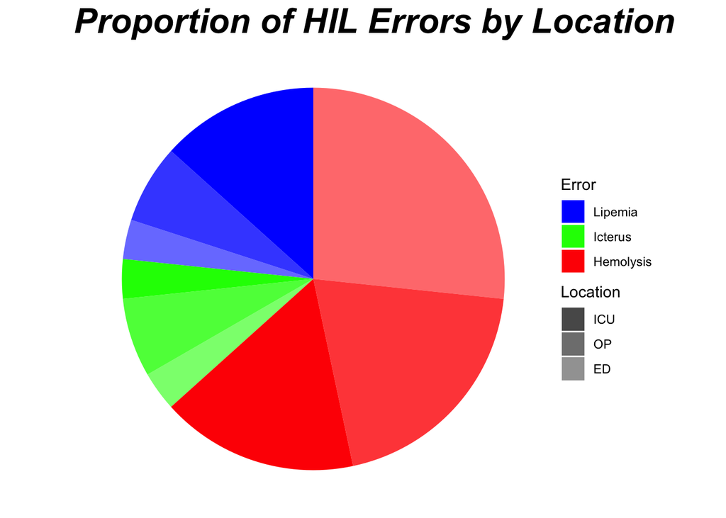

```r
toy_hil_data <-
  tibble(Location = c("ED", "ICU", "OP"), Hemolysis = c(0.8, 0.5, 0.6), Icterus = c(0.1, 0.1, 0.2), Lipemia = c(0.1, 0.4, 0.2)) |>
    pivot_longer(-Location, names_to = "Error", values_to = "Proportion") |>
    mutate(Error = factor(Error, levels = c("Lipemia", "Icterus", "Hemolysis")), Location = factor(Location, levels = c("ICU", "OP", "ED")))

# Make baseline pie chart
toy_hil_data |>
  ggplot(aes(x = "", y = Proportion, fill = Error, alpha = Location)) +
    geom_bar(width = 1, stat = "identity") +
    scale_fill_manual(values = c("blue", "green", "red")) +
    scale_alpha_manual(values = c(1, 0.8, 0.6)) +
    coord_polar("y", start = 0) +
    ggtitle("Proportion of HIL Errors by Location") +
    theme_void() +
    theme(plot.title = element_text(size = 24, face = "bold.italic", hjust = 0))
```

- This pie chart highlights the proportion of HIL errors by location.  
- The *size* of the pie chart represents the *proportion* of errors.  
- The *color* represents the *type* of error.  
- The *transparency* represents the *clinical context* for the error

**Good**

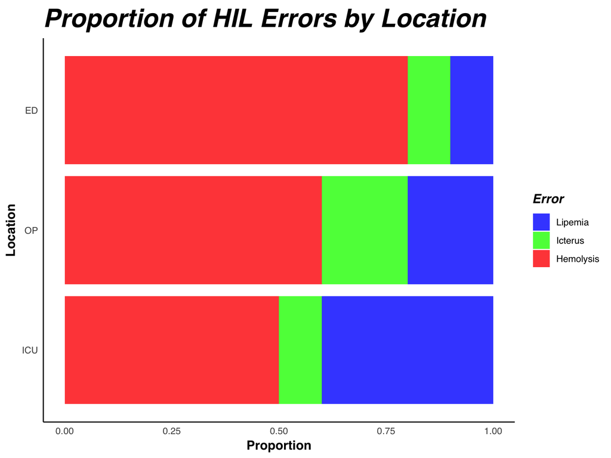

```r
toy_hil_data |>
  ggplot(aes(x = Proportion, y = Location, fill = Error)) +
    geom_col(alpha = 0.8) +
    scale_fill_manual(values = c("blue", "green", "red")) +
    scale_alpha_manual(values = c(1, 0.8, 0.6)) +
    ggtitle("Proportion of HIL Errors by Location") +
    theme(plot.title = element_text(size = 24, face = "bold.italic", hjust = 0))
```

**Questions**

1. What makes this version better than the pie chart?
2. What can still be improved?

**Answers**

1. This version is better than the pie chart because the **absolute and relative quantities are easier to interpret** in the stacked bar chart.
2. Improvements can still be made in the **clarity of the labels and the color scheme**.

**Better**

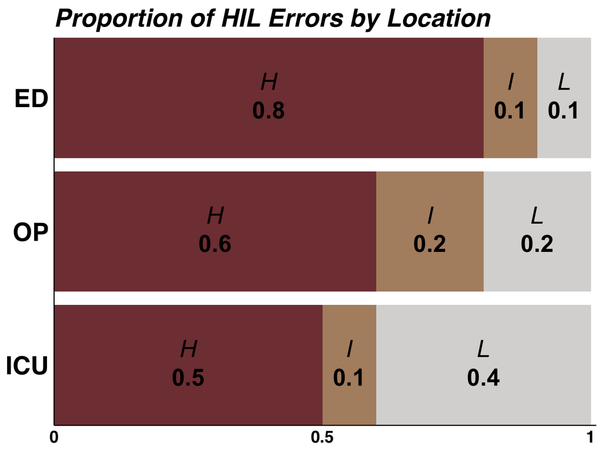

```r
toy_hil_data |>
  mutate(label = glue::glue("*{str_sub(Error, 1, 1)}*<br>**{Proportion}**")) |>
  ggplot(aes(x = Proportion, y = Location, fill = Error)) +
    geom_col(alpha = 0.9) +
    ggtext::geom_richtext(aes(label = label), position = position_stack(vjust = 0.5), size = 8, fill = NA, label.color = NA) +
    scico::scale_fill_scico_d(palette = "bilbao", begin = 0.9, end = 0.1) +
    scale_alpha_manual(values = c(1, 0.8, 0.6)) +
    scale_x_continuous(labels = c("0", "0.5", "1"), breaks = c(0, 0.5, 1), expand = expansion(mult = c(0, 0.01))) +
    scale_y_discrete(expand = expansion(mult = c(0.1, 0.1))) +
    ggtitle("Proportion of HIL Errors by Location") +
    theme(plot.title = element_text(size = 24, face = "bold.italic", hjust = 0), legend.position = "none", axis.title.y.left = element_blank(), axis.text.y.left = element_text(size = 24, face = "bold", color = "black"), axis.text.x.bottom = element_text(size = 16, face = "bold", color = "black"), axis.title.x.bottom = element_blank())
```

**Questions**

1. What improvements are made in this version?
2. What can still be improved?

**Answers**

1. This version **improves clarity by directly labeling** the graph with the relevant annotations and removing the legend.  
   It also uses a color-blind friendly color palette that **invokes the types of errors the colors represent**.
2. Improvements can still be in how easy it is to **compare across groups**.

**Best**

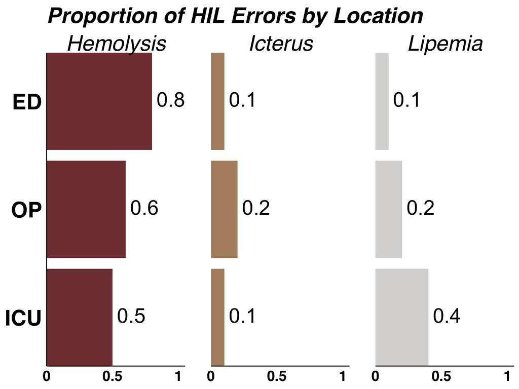

```r
toy_hil_data |>
  mutate(label = glue::glue("*{str_sub(Error, 1, 1)}*<br>**{Proportion}**")) |>
  ggplot(aes(x = Proportion, y = Location, fill = Error)) +
    geom_col(alpha = 0.9) +
    ggtext::geom_richtext(aes(label = Proportion), nudge_x = 0.01, hjust = 0, size = 8, fill = NA, label.color = NA) +
    facet_wrap(~fct_rev(Error), ncol = 3) +
    scico::scale_fill_scico_d(palette = "bilbao", begin = 0.9, end = 0.1) +
    scale_alpha_manual(values = c(1, 0.8, 0.6)) +
    scale_x_continuous(limits = c(0, 1), labels = c("0", "0.5", "1"), breaks = c(0, 0.5, 1), expand = expansion(mult = c(0, 0.05))) +
    scale_y_discrete(expand = expansion(mult = c(0.1, 0.1))) +
    coord_cartesian(clip = "off") +
    ggtitle("Proportion of HIL Errors by Location") +
    theme(plot.title = element_text(size = 24, face = "bold.italic", hjust = 0), legend.position = "none", axis.title.y.left = element_blank(), axis.text.y.left = element_text(size = 24, face = "bold", color = "black"), axis.text.x.bottom = element_text(size = 16, face = "bold", color = "black"), axis.title.x.bottom = element_blank(), strip.text = element_text(size = 24, face = "italic", color = "black"), strip.clip = "off", panel.spacing.x = unit(2, "lines"))
```

**Questions**

1. What improvements are made in this version?
2. What trade-offs are made for this improvement?

**Answers**

1. This version **simplifies the direct comparisons across contexts** by aligning them vertical across different facets.
2. Breaking the bars into separate facets **fills up more space**.

# Exercise 2: Geospatial Analysis

```r
# Set Up Geospatial Data
Sys.setenv(PROJ_LIB = "/usr/local/share/proj")  # Adjust this path as needed
Sys.setenv(GDAL_DATA = "/usr/local/share/gdal")  # Adjust this path as needed

# Install required packages if not already installed
if (!requireNamespace("sf", quietly = TRUE)) {
  install.packages("sf")
}
if (!requireNamespace("terra", quietly = TRUE)) {
  install.packages("terra")
}
if (!requireNamespace("sp", quietly = TRUE)) {
  install.packages("sp")
}

# Load libraries
library(sf)
library(terra)
library(sp)
library(tidyverse)

my_sf <- read_sf("~/git/educational_materials/DataViz/visualizing-laboratory-data-adlm/visualizing-laboratory-data/inputs/od_shapefile_illinois.shp")
```

## Example 1: Choosing the Appropriate Variable

**Base**

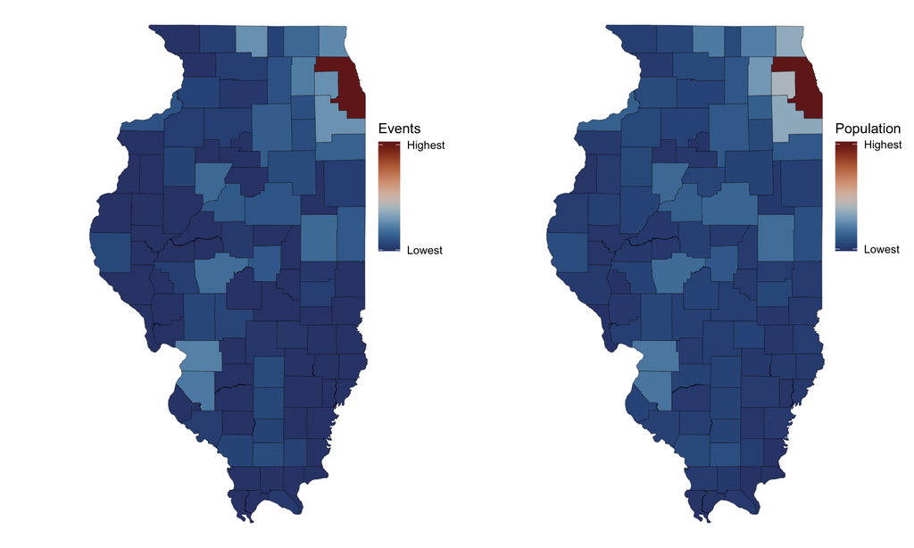

```r
## Make Population Map
gg_pop_diverg <-
  ggplot(my_sf) +
    geom_sf(aes(fill = DP05_0001E), color = "black", linewidth = 0.1) +
    scico::scale_fill_scico(palette = "vikO", begin = 0.15, end = 0.85, trans = scales::sqrt_trans(), breaks = c(10000, 5000000), labels = c("Lowest", "Highest")) +
    guides(fill = guide_colorbar(title ="Population", direction = "vertical")) +
    theme_void() +
    coord_sf(expand = T, clip = "off") +
    theme(legend.position = c(1.1, 0.66), legend.title.position = "top")

## Make Absolute Count Map
gg_od_abs <-
  ggplot(my_sf) +
    geom_sf(aes(fill = od_abs), color = "black", linewidth = 0.1) +
    scico::scale_fill_scico(palette = "vikO", begin = 0.15, end = 0.85, trans = scales::sqrt_trans(), breaks = c(10, 100000), labels = c("Lowest", "Highest")) +
    guides(fill = guide_colorbar(title ="Events", direction = "vertical")) +
    theme_void() +
    coord_sf(expand = T, clip = "off") +
    theme(legend.position = c(1.1, 0.66), legend.title.position = "top")

## Combine Them
ggpubr::ggarrange(gg_od_abs, gg_pop_diverg, ncol = 2, common.legend = F)
```

**Better**

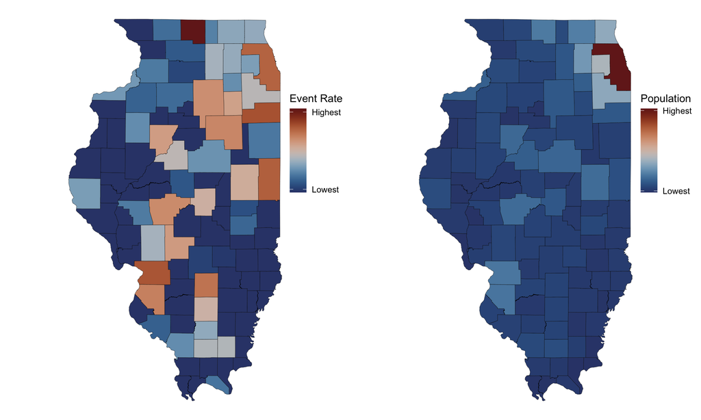

```r
## Make Population Map
gg_pop_diverg <-
  ggplot(my_sf) +
    geom_sf(aes(fill = DP05_0001E), color = "black", linewidth = 0.1) +
    scico::scale_fill_scico(palette = "vikO", begin = 0.15, end = 0.85, trans = scales::sqrt_trans(), breaks = c(10000, 5000000), labels = c("Lowest", "Highest")) +
    guides(fill = guide_colorbar(title ="Population", direction = "vertical")) +
    theme_void() +
    coord_sf(expand = T, clip = "off") +
    theme(legend.position = c(1.1, 0.66), legend.title.position = "top")

## Make Absolute Count Map
gg_od_pct <-
  ggplot(my_sf) +
    geom_sf(aes(fill = od_pct), color = "black", linewidth = 0.1) +
    scico::scale_fill_scico(palette = "vikO", begin = 0.15, end = 0.85, breaks = c(0.001, 0.026), labels = c("Lowest", "Highest")) +
    guides(fill = guide_colorbar(title ="Event Rate", direction = "vertical")) +
    theme_void() +
    theme(legend.position = c(1.1, 0.66), legend.title.position = "top")

## Combine Them
ggpubr::ggarrange(gg_od_pct, gg_pop_diverg, ncol = 2, common.legend = F)
```

**Best**

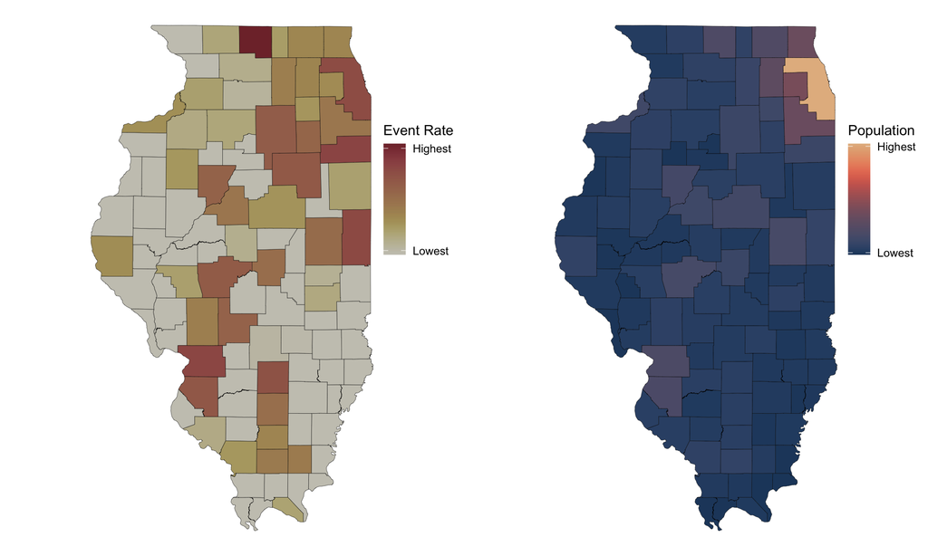

```r
## Make Population Map
gg_pop_sequential <-
  ggplot(my_sf) +
    geom_sf(aes(fill = DP05_0001E), color = "black", linewidth = 0.1) +
    scico::scale_fill_scico(palette = "lipari", begin = 0.15, end = 0.85, trans = scales::sqrt_trans(), breaks = c(10000, 5000000), labels = c("Lowest", "Highest")) +
    guides(fill = guide_colorbar(title ="Population", direction = "vertical")) +
    theme_void() +
    theme(legend.position = c(1.1, 0.66), legend.title.position = "top")

## Make Absolute Count Map
gg_od_pct_seq <-
  ggplot(my_sf) +
    geom_sf(aes(fill = od_pct), color = "black", linewidth = 0.1) +
    scico::scale_fill_scico(palette = "bilbao", begin = 0.85, end = 0.15, breaks = c(0.001, 0.026), labels = c("Lowest", "Highest")) +
    guides(fill = guide_colorbar(title ="Event Rate", direction = "vertical")) +
    theme_void() +
    theme(legend.position = c(1.1, 0.66), legend.title.position = "top")

## Combine Them
ggpubr::ggarrange(gg_od_pct_seq, gg_pop_sequential, ncol = 2, common.legend = F)
```

# Exercise 3: Dashboards

## Exploring a Real-World Dashboard

[figure not shown]

Talking Points: - Who is the target audience? - What metrics are most relevant? - Does the current design acheive the goals? - Is the information clear, concise, and easy to understand? - What could be removed or added?